# MCCA_Skills

Aurora Martinez del Rio

2025-02-21

## Getting Started

After loading in my data sets and libraries for data manipulation, statistics, and visualization, the two different data sets are combined using the shared firm name key. Before doing any exploratory data analysis, I also added two additional columns: 1) the proportion of minority attorneys in each firm and 2) the proportion of female attorneys in each firm.

## Data Exploration

Some introductory data exploration shows fairly wide variation in the size of firms, with firm size ranging from 1 to 1000. MCCA scores have a wide distributions between 0 and 1, with the median falling almost exactly halfway between the two highest and lowest scores. This suggests considerable differences in performance metrics across the different firms, with scores distributed fairly equally across the possible values.

There Descriptive stats also show considerably more programs without DEI programs (651) than with DEI programs (169). The average number of minority attorneys (mean: 75.43) at the firms within the data set was much smaller than the number of female attorneys (mean: 250). A similar difference was seen between the average proportion of minority attorneys at each firm (mean: 15%) when comparing it to the average proportion of female attorneys (mean: 50%).

An overview of some of the data sets descriptive statistics can be seen below:

```
##  count_attorneys  binary_has_dei_program  firm_name          count_female
##  Min.   :   1.0   Mode :logical          Length:820         Min.   :  0.0
##  1st Qu.: 264.8   FALSE:651              Class :character   1st Qu.:125.8
##  Median : 502.5   TRUE :169              Mode  :character   Median :234.0
##  Mean   : 502.8                                             Mean   :250.0
##  3rd Qu.: 747.0                                             3rd Qu.:353.0
##  Max.   :1000.0                                             Max.   :684.0
##  count_minority     mcca_score        PropMinority       PropFemale
##  Min.   :  0.00   Min.   :0.004966   Min.   :0.00000   Min.   :0.0000
##  1st Qu.: 20.75   1st Qu.:0.256622   1st Qu.:0.07819   1st Qu.:0.4005
##  Median : 57.50   Median :0.492337   Median :0.15175   Median :0.5000
##  Mean   : 75.43   Mean   :0.500693   Mean   :0.15008   Mean   :0.5004
##  3rd Qu.:116.00   3rd Qu.:0.745234   3rd Qu.:0.22989   3rd Qu.:0.5984
##  Max.   :288.00   Max.   :0.998426   Max.   :0.30769   Max.   :0.7000
```

As, later, we will be performing statistical analysis on the data, we also want to check the distribution of the variables of interest for skew. This also provides a better idea of the distribution of the different variables I’m looking at. As seen by the values below, none of the variables are not strongly skewed. However, the count of minority attorneys at each firm is slightly right skewed, with firms trending towards having a smaller number of minority attorneys. This trend is shown through a density plot as well.

```
## [1] "Skew for the number of minority attorneys, followed by kurtosis"
```

```
## [1] 0.8931576
```

```
## [1] 3.021095
```

```
## [1] "Skew of the count of female attorneys"
```

```
## [1] 0.3679068
```

```
## [1] "Skew of the MCCA score"
```

```
## [1] -9.961001e-05
```

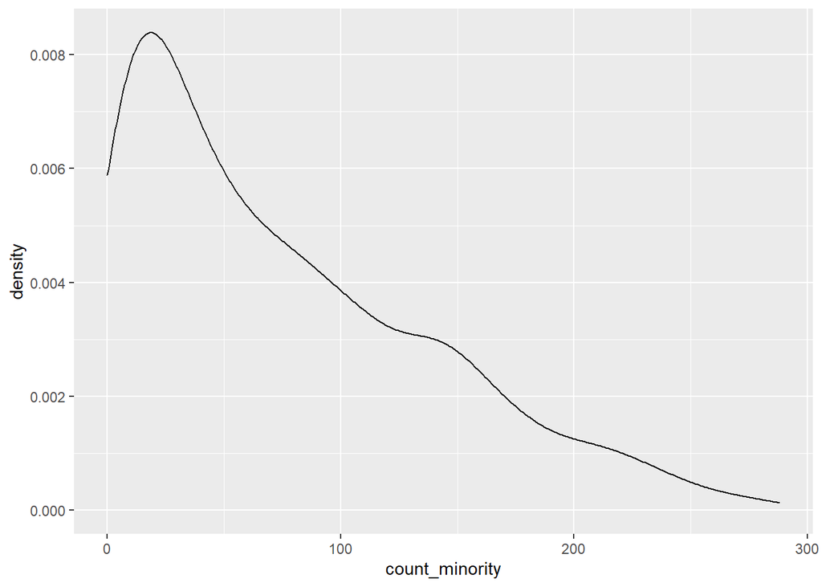

## Visualizing trends in the data

Below are a series of data visualizations. These include a couple of scatter plots mapping the relationship between the number of female attorneys to total number of attorneys in each firm, as well as the number of minority attorneys to the total number of attorneys in each firm. A regression line is included for both of these. Interestingly, there appears to be a steeper positive relationship between the number of female attorneys at each firm and total number of attorneys, than there is between the number of minority attorneys and total number of attorneys.

Each firm’s MCCA score is also plotted alongside the proportion of minority attorneys and, separately, proportion of female attorneys. At first glace, there doesn’t seem to be a strong relationship between these variables, in either a positive or negative directions.

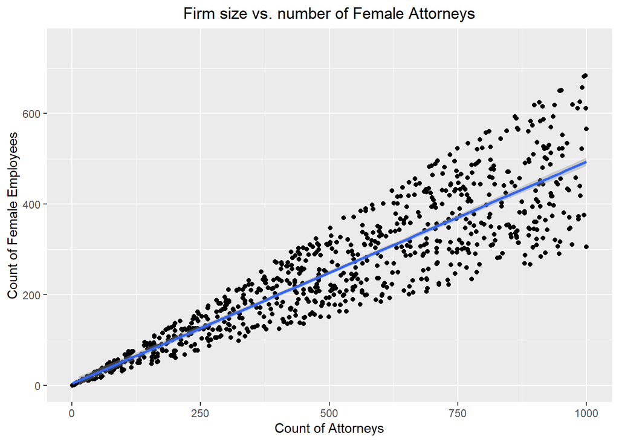

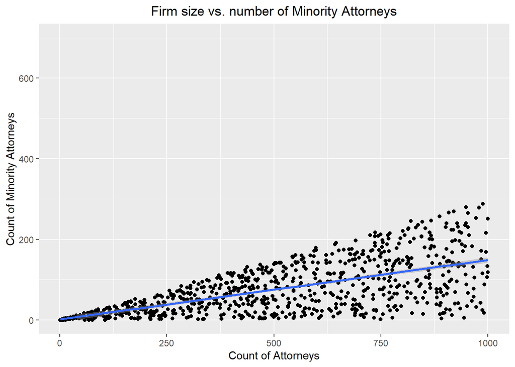

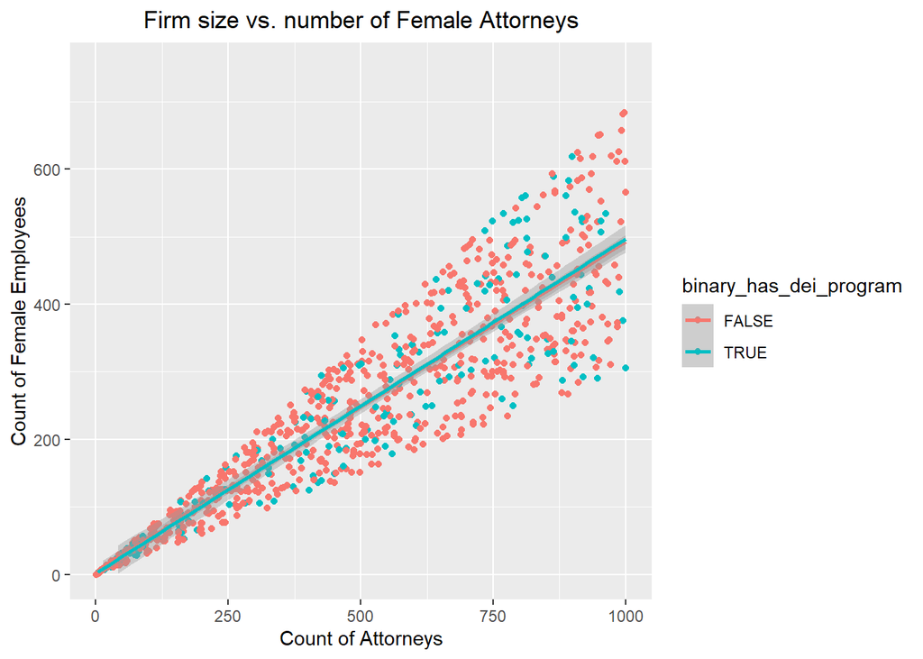

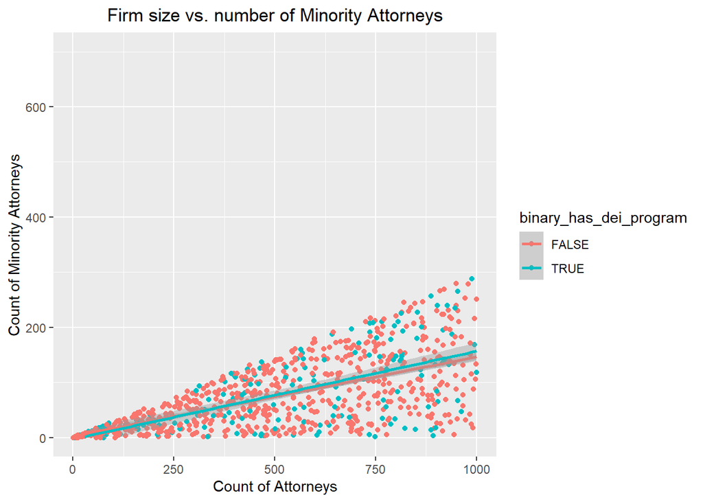

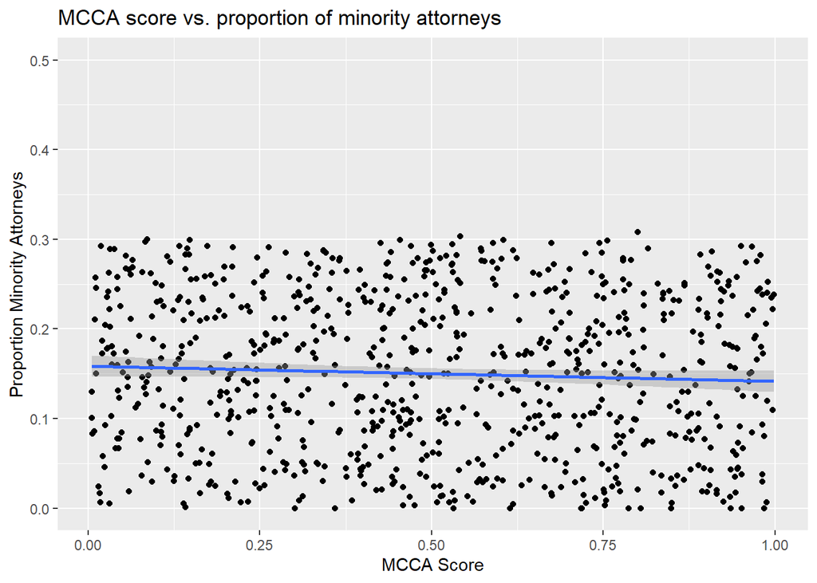

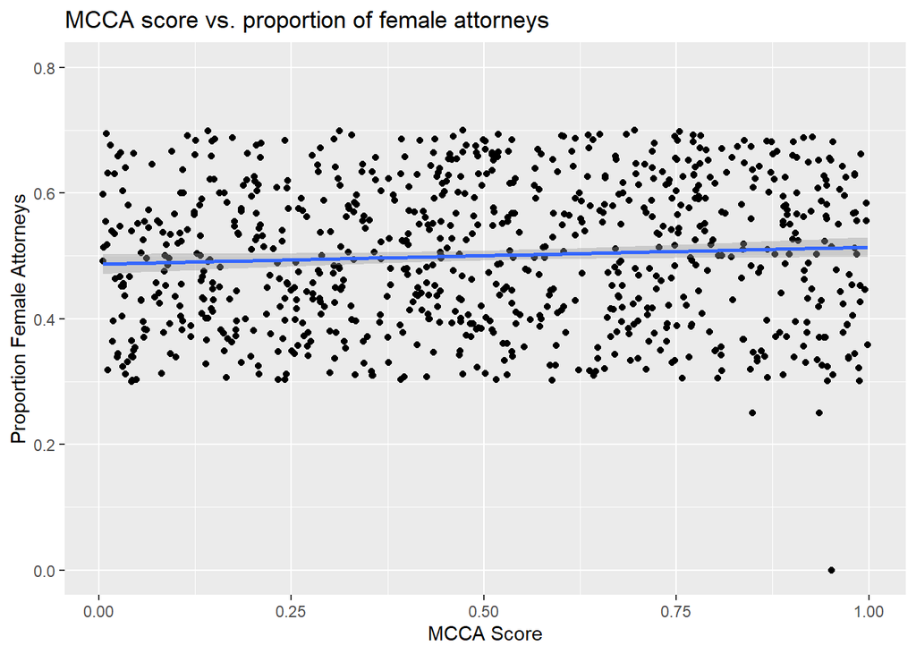

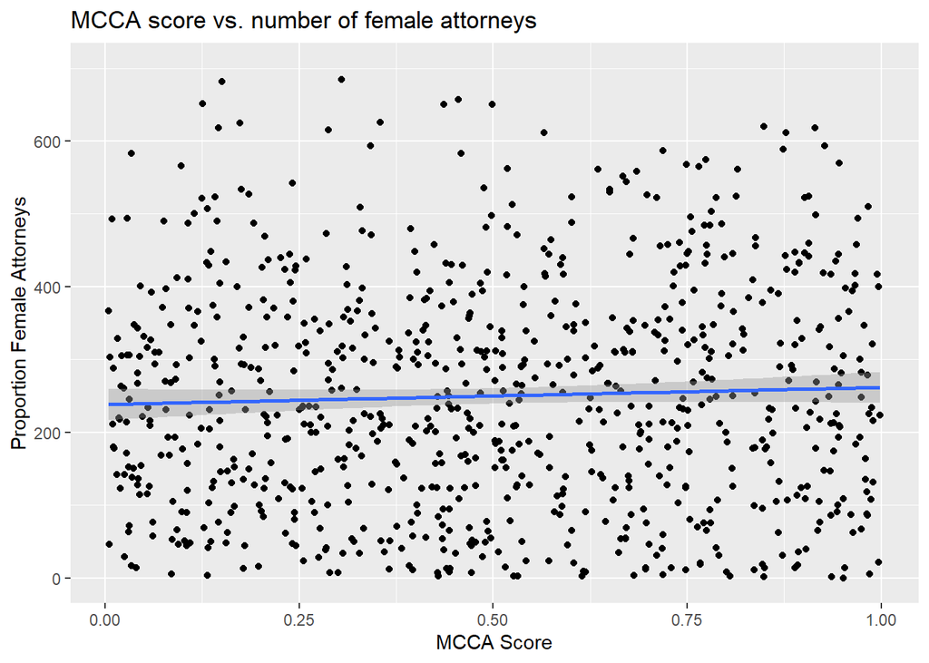

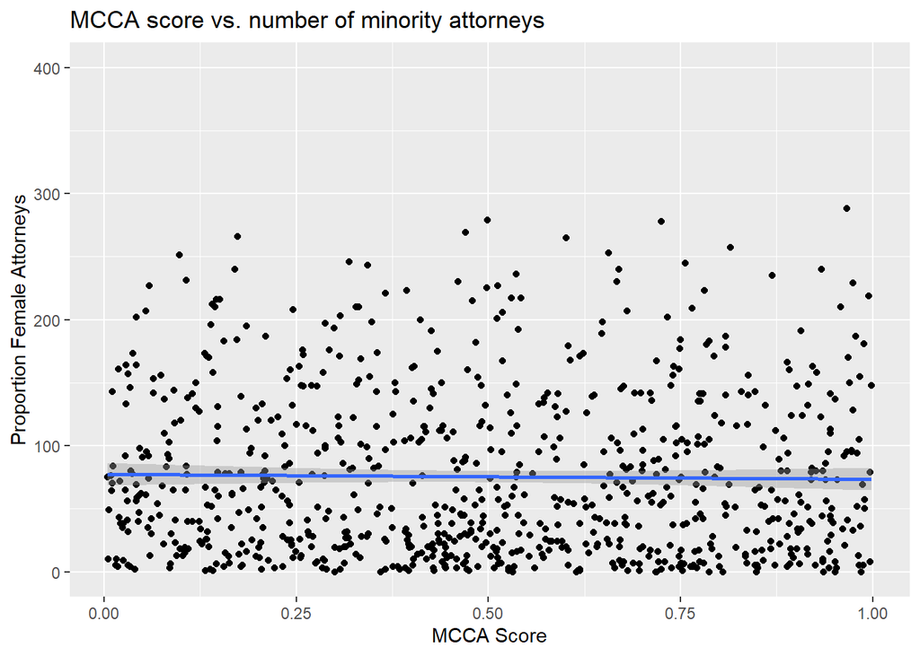

The series of scatter plots are followed by a histogram looking at the relationship between average MCCA score and whether or not a firm has a DEI program. Aside from differences in variance between the sets of firms with and without DEI programs, the plot does not show a considerable difference in averages. This is followed by a set of histograms looking at the relationship between the proportion of firms that are female or are minorities, dividing the data by whether or not the firm has a DEI program. Visual examination of these visuals doesn’t reveal prominent differences between average proportions of female attorneys for firms with and without DEI programs, nor does it show a prominent different in between the proportion of minority attorneys at firms with and without DEI programs.

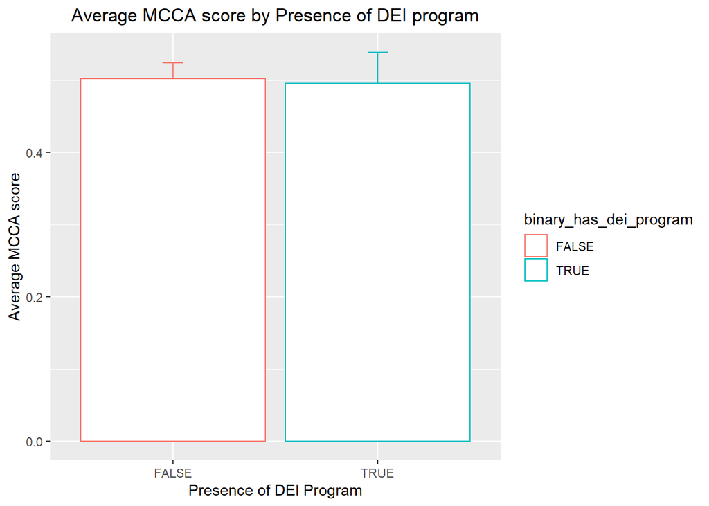

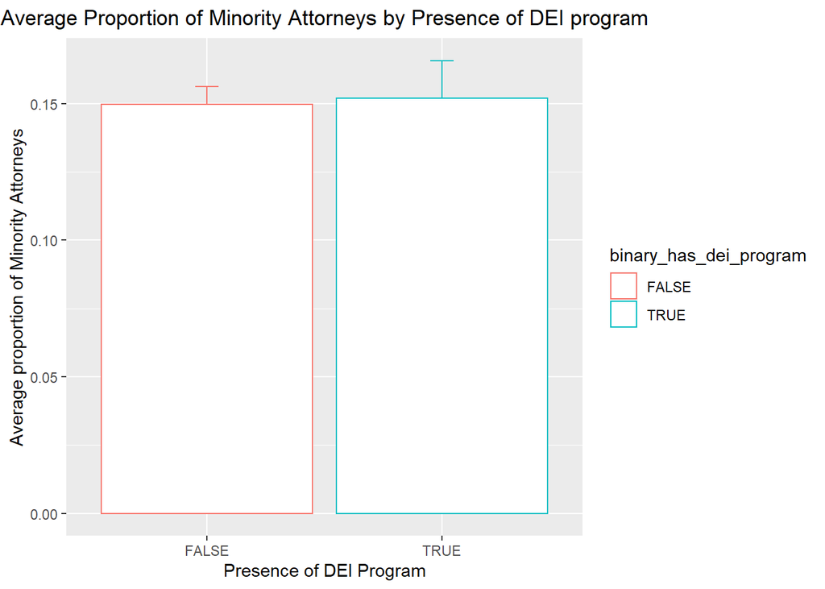

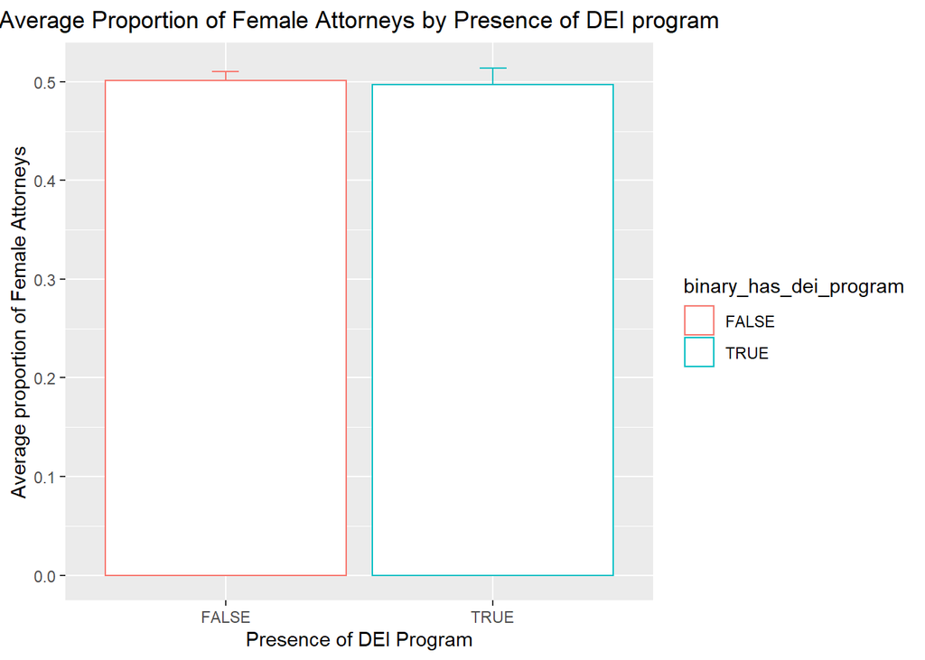

## Regression analysis for MCCA score

The regression run below tests whether having a DEI program significantly predicted the MCCA score. The regression model (Regression 1) did not show a significant relationship between MCCA score and whether a firm had a DEI program. This does not support a hypothesis that having a DEI program increases the likelihood of having a higher MCCA score.

A follow-up regression analysis (Regression 2), including other predictor variables like number of female attorneys and number of minority attorneys performed similarly. None of the predictor variables tested showed a significant relationship witht the MCCA score.

```
## [1] "REgression 1"
```

```
##
## Call:
## lm(formula = mcca_score ~ binary_has_dei_program, data = FullData)
##
## Residuals:
##      Min       1Q   Median       3Q      Max
## -0.49701 -0.24383 -0.00819  0.24591  0.49645
##
## Coefficients:
##                             Estimate Std. Error t value Pr(>|t|)
## (Intercept)                 0.501978   0.011184  44.884   <2e-16 ***
## binary_has_dei_programTRUE -0.006232   0.024635  -0.253      0.8
## ---
## Signif. codes:  0 '***' 0.001 '**' 0.01 '*' 0.05 '.' 0.1 ' ' 1
##
## Residual standard error: 0.2854 on 818 degrees of freedom
## Multiple R-squared:  7.822e-05,  Adjusted R-squared:  -0.001144
## F-statistic: 0.06399 on 1 and 818 DF,  p-value: 0.8004
```

```
## [1] "Regression 2"
```

```
##
## Call:
## lm(formula = mcca_score ~ binary_has_dei_program + count_female +
##     count_minority, data = FullData)
##
## Residuals:
##      Min       1Q   Median       3Q      Max
## -0.52896 -0.23777 -0.00467  0.23956  0.52037
##
## Coefficients:
##                              Estimate Std. Error t value Pr(>|t|)
## (Intercept)                 4.858e-01  1.965e-02  24.719   <2e-16 ***
## binary_has_dei_programTRUE -6.841e-03  2.465e-02  -0.277   0.7815
## count_female                1.485e-04  7.904e-05   1.878   0.0607 .
## count_minority             -2.761e-04  1.880e-04  -1.469   0.1423
## ---
## Signif. codes:  0 '***' 0.001 '**' 0.01 '*' 0.05 '.' 0.1 ' ' 1
##
## Residual standard error: 0.285 on 816 degrees of freedom
## Multiple R-squared:  0.004663,   Adjusted R-squared:  0.001004
## F-statistic: 1.274 on 3 and 816 DF,  p-value: 0.282
```

## Moving files up to GitHub

git branch technical-screen